# German credit risk

ANHG

2023-01-24

```r
# Incluir knitr para visualización de tablas
library(knitr)
# Incluir Tidyverse para analisis de datos
library(tidyverse)
# Incluir la librería dataexplorer para exploracion de datos
library(DataExplorer)
```

# Obtención de datos

```r
library(readr)
german_credit_data <- read_csv("Inputs/german_credit_data.csv")
```

```
## ──────────────────────────────────────────────────────── Delimiter: "," chr
## (6): Sex, Housing, Saving accounts, Checking account, Purpose, Risk dbl (5):
## ...1, Age, Job, Credit amount, Duration
```

```r
kable(head(german_credit_data))
```

| …1 | Age | Sex | Job | Housing | Saving accounts | Checking account | Credit amount | Duration | Purpose | Risk |
| --- | --- | --- | --- | --- | --- | --- | --- | --- | --- | --- |
| 0 | 67 | male | 2 | own | NA | little | 1169 | 6 | radio/TV | good |
| 1 | 22 | female | 2 | own | little | moderate | 5951 | 48 | radio/TV | bad |
| 2 | 49 | male | 1 | own | little | NA | 2096 | 12 | education | good |
| 3 | 45 | male | 2 | free | little | little | 7882 | 42 | furniture/equipment | good |
| 4 | 53 | male | 2 | free | little | little | 4870 | 24 | car | bad |
| 5 | 35 | male | 1 | free | NA | NA | 9055 | 36 | education | good |

# Exploración de los datos

Comenzamos con al pregunta de investigación ¿El prestamo a un cliente prospecto tendrá riesgo bueno o malo?

## Summary

```r
summary(german_credit_data)
```

```
##       ...1            Age            Sex                 Job
##  Min.   :  0.0   Min.   :19.00   Length:1000        Min.   :0.000
##  1st Qu.:249.8   1st Qu.:27.00   Class :character   1st Qu.:2.000
##  Median :499.5   Median :33.00   Mode  :character   Median :2.000
##  Mean   :499.5   Mean   :35.55                      Mean   :1.904
##  3rd Qu.:749.2   3rd Qu.:42.00                      3rd Qu.:2.000
##  Max.   :999.0   Max.   :75.00                      Max.   :3.000
##    Housing          Saving accounts    Checking account   Credit amount
##  Length:1000        Length:1000        Length:1000        Min.   :  250
##  Class :character   Class :character   Class :character   1st Qu.: 1366
##  Mode  :character   Mode  :character   Mode  :character   Median : 2320
##                                                           Mean   : 3271
##                                                           3rd Qu.: 3972
##                                                           Max.   :18424
##     Duration      Purpose              Risk
##  Min.   : 4.0   Length:1000        Length:1000
##  1st Qu.:12.0   Class :character   Class :character
##  Median :18.0   Mode  :character   Mode  :character
##  Mean   :20.9
##  3rd Qu.:24.0
##  Max.   :72.0
```

Features categóricas: Sex Housing Saving accounts Checking account Purpose Risk

Features Continuas: Index Age Job Credit amount Duration

Vemos que - Hay 1000 Observaciones - El promedio de edad es de 35 años - En promedio se prestan 3271 dolares - La duración promedio es de 20 meses

## Summary (Plot)

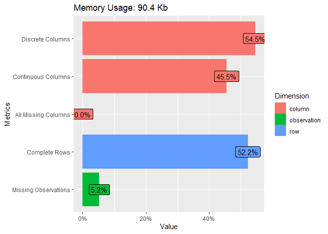

```r
plot_intro(german_credit_data)
```

- El 50% de las columnas tiene filas completas. Tenemos un 5.2% de obserbaciones sin datos. - Casi la mitad de las columnas son continuas.

## Datos faltantes

### Gráfico

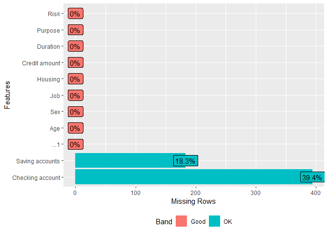

```r
plot_missing(german_credit_data)
```

- Checking account tiene un 39.4% de datos faltantes.

## Mapa de calor

```
## 1 features with more than 5 categories ignored!
## Purpose: 8 categories
```

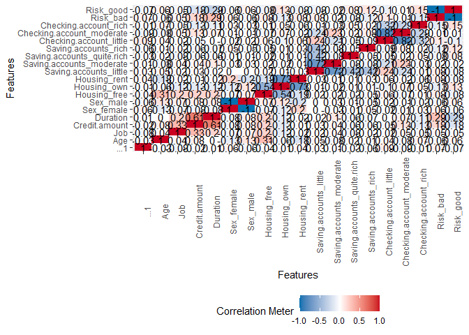

```r
plot_correlation(na.omit(german_credit_data), maxcat = 5L,  type = c("all", "discrete", "continuous"))
```

- En el mapa de correlación podemos observar que tienen mayor correlación con el riesgo - Credit amount - Duration - Housing own - Saving accounts rich - Checking accounts rich

# Limpieza de datos

- Job está muy correlacionado con credit amount, pero poco con el riesgo por lo que creo que quitar esa variable no afectaría mucho. Sin embargo para análisis y segmentación abona de la misma manera que el sexo.
- No encuentro nada que sea estrictamente necesario cambiar.

## Revisemos la distribución de frecuencia

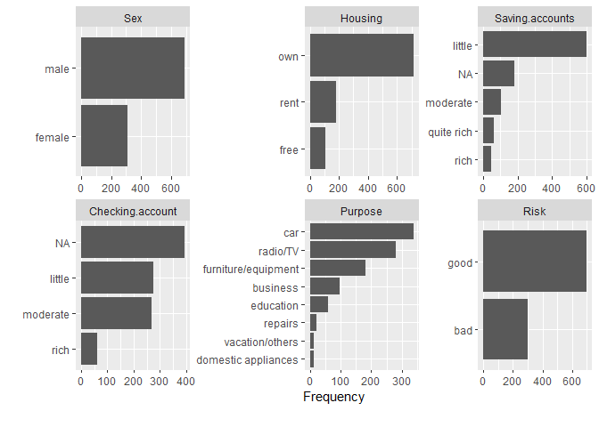

```r
plot_bar(german_credit_data)
```

## Un gráfico interesantes es el de la distribución de frecuencia por Sexo, Riesgo, Propósito

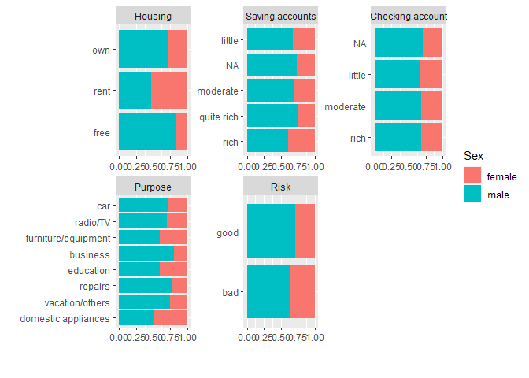

```r
plot_bar(german_credit_data, by = "Sex")
```

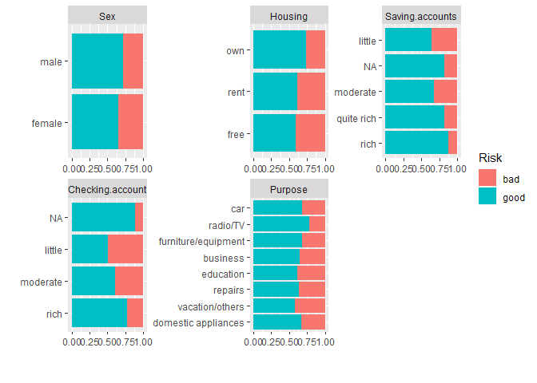

```r
plot_bar(german_credit_data, by = "Risk")
```

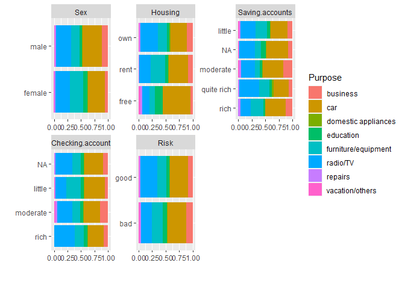

```r
plot_bar(german_credit_data, by = "Purpose")
```

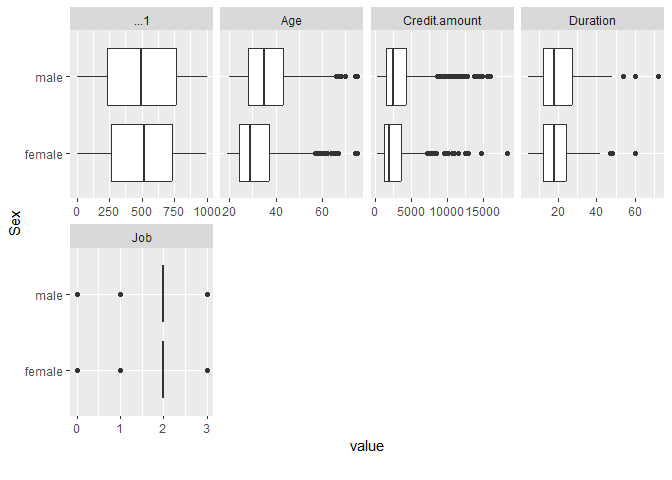

```r
plot_boxplot(german_credit_data, by = "Sex")
```

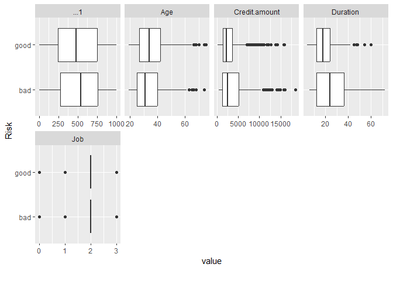

```r
plot_boxplot(german_credit_data, by = "Risk")
```

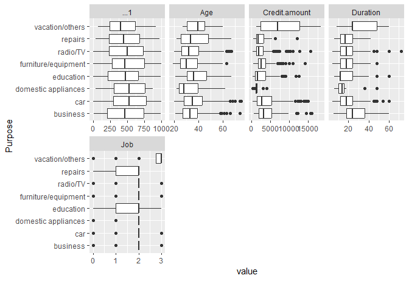

```r
plot_boxplot(german_credit_data, by = "Purpose")
```